# Machine Learning para detección de Fraude

### 2.1.2 Predinástico tardío

Medidas de posición central

```r
# Se obtienen en un dataframe el número de observaciones, la media, mediana y
# moda
predi_tardio %>%
  summarise(
          Epoca = "Predinástico Tardío",
          Observaciones = n(),
          Media = mean(Anchura_del_craneo, na.rm = TRUE),
          Mediana = median(Anchura_del_craneo, na.rm = TRUE),
          Moda =Mode(Anchura_del_craneo),
          )
```

```
##                 Epoca Observaciones    Media Mediana Moda
## 1 Predinástico Tardío            30 132.4667     133  133
```

Medidas de posición no centrales

```r
# Se obtienen sólo las divisiones para 5 tramos por no hacer información
# redundante
quantile(predi_tardio$Anchura_del_craneo)
```

```
##   0%  25%  50%  75% 100%
##  131  132  133  133  135
```

Medidas de dispersión

```r
# Se obtienen en un dataframe el mínimo y máximo para el rango, la varianza, la
# desviación típica y el coeficiente de variación de Pearson
predi_tardio %>%
  summarise(
          Epoca = "Predinástico Tardío",
          Min = min(Anchura_del_craneo),
          Max = max(Anchura_del_craneo),
          Varianza = var(Anchura_del_craneo, na.rm = TRUE),
          Des_Tipica = sd(Anchura_del_craneo, na.rm = TRUE),
          CV_Pearson = coef_var(Anchura_del_craneo),
          )
```

```
##                 Epoca Min Max Varianza Des_Tipica  CV_Pearson
## 1 Predinástico Tardío 131 135 1.016092   1.008014 0.007609566
```

Medidas de forma

```r
# Se obtienen en un dataframe el el coeficiente de asimetría y la curtosis
predi_tardio %>%
  summarise(
          Epoca = "Predinástico Tardío",
          Asimetria = skew(Anchura_del_craneo, na.rm = TRUE),
          Curtosis = kurtosi(Anchura_del_craneo, na.rm = TRUE),
          )
```

```
##                 Epoca Asimetria   Curtosis
## 1 Predinástico Tardío  0.185432 -0.3706948
```

Diagrama de caja y bigotes

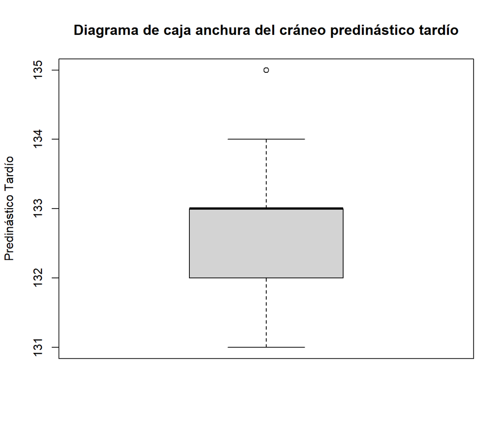

```r
# Se dibuja un boxplot para la anchura del cráneo
boxplot(predi_tardio$Anchura_del_craneo,
        ylab="Predinástico Tardío",
        main="Diagrama de caja anchura del cráneo predinástico tardío")
```

Pasando a las medidas de rango y dispersión, el mínimo y máximo en el cráneos del Ptem es 1cm inferior a lo encontrado en los cráneos del Ptar, algo que se traslada al resto de cuartiles, dando la sensación de que en el segundo período la distribución está desplazada hacia una mayor anchura. Por el lado de la varianza y la desviación típica, vemos que son de las medidas que más diferencia presentan entre períodos, siendo el Ptar el que presenta una mayor variabilidad. Aún así, el coeficiente de variación queda muy cercano a 0 en ambos casos lo cual implica que la media es un valor robusto y muy explicativo al no variar en exceso los datos respecto a ella.

## 2.2 Apartado b

En este aprtado se comprobará la normalidad de ambos subgrupos de la muestra. No se pide en el enunciado, puede ser representativo el hacer un histograma junto con la densidad de la distribución pese a que al haber tan poca muestra no sean del todo fiables

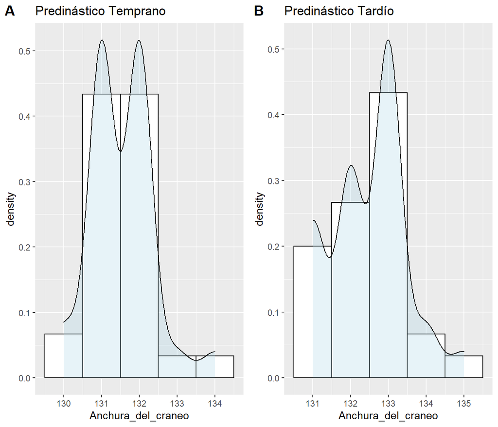

```r
plot_temp<-ggplot(predi_temprano,aes(x=Anchura_del_craneo))+
    geom_histogram(aes(y=..density..),colour="black",fill="white", bins = 5)+
    geom_density(alpha=.3,fill="light blue")+
    ggtitle("Predinástico Temprano")

plot_tard<-ggplot(predi_tardio,aes(x=Anchura_del_craneo))+
    geom_histogram(aes(y=..density..),colour="black",fill="white", bins = 5)+
    geom_density(alpha=.3,fill="light blue")+
    ggtitle("Predinástico Tardío")

plot_grid(plot_temp, plot_tard, labels = "AUTO")
```

Los resultado demuestran claramente distribuciones no normales, con varias “montañas” y asimetría en las distribuciones de densidad, pero se deberá confirmar con algún contraste de hipótesis. El test de Kolmogorov-Smirnov no debería aplciarse aquí porque hay un número muy pequeño de datos, no se conocen la media y varianza poblacional y hay varios elementos de la distribución repetidos. Tampoco sería ideal usar el test de Lilliefors pues el tamaño de la muestra es inferior a los 50 individuos recomendables de manera que se empleará para contrastar el test de Saphiro-Wilk:

```r
# Test de Shapiro-Wilk para Ptemp
shapiro.test(predi_temprano$Anchura_del_craneo)
```

```
##
##  Shapiro-Wilk normality test
##
## data:  predi_temprano$Anchura_del_craneo
## W = 0.83781, p-value = 0.0003481
```

Como el p-valor es muy cercano a 0 e inferior a un alpha de 0.05, se puede rechazar la hipótesis nula de normalidad para una confianza del 5% e incluso el 1%. La anchura de los cráneos del predinástico temprano no sigue una distribución normal

```r
# Test de Shapiro-Wilk para PTar
shapiro.test(predi_tardio$Anchura_del_craneo)
```

```
##
##  Shapiro-Wilk normality test
##
## data:  predi_tardio$Anchura_del_craneo
## W = 0.8832, p-value = 0.003341
```

Como el p-valor es muy cercano a 0 e inferior a un alpha de 0.05, se puede rechazar la hipótesis nula de normalidad para una confianza del 5% e incluso el 1%. La anchura de los cráneos del predinástico tardío tampoco sigue una distribución normal

# 3 Pregunta 2

## 3.1 Apartados a y b

En este apartado se está ante un caso de obtención del intervalo de confianza para la diferencia de medias en poblaciones no normales y con varianzas desconocidas. El enunciado por su parte, nos indica que asumamos independencia de muestras. Faltaría por comprobar si ambas muestras poseen igualdad de varianzas algo que se puede ver con el test de Levene:

```r
leveneTest(predi_temprano$Anchura_del_craneo,predi_tardio$Anchura_del_craneo)
```

```
## Levene's Test for Homogeneity of Variance (center = median)
##       Df F value Pr(>F)
## group  4  0.4388 0.7793
##       25
```

Con estas características hay un problema, pues los intervalos y la forma de calcularlos implican que las distribuciones sean normales, cuando realmente no lo son. Aún así, a efectos del ejercicio se procederá a su cálculo y a discutir las implicaciones:

Intervalo al 0.9:

```r
t.test(predi_temprano$Anchura_del_craneo, predi_tardio$Anchura_del_craneo,
       conf.level = 0.9, var.equal = TRUE)
```

```
##
##  Two Sample t-test
##
## data:  predi_temprano$Anchura_del_craneo and predi_tardio$Anchura_del_craneo
## t = -3.9354, df = 58, p-value = 0.0002248
## alternative hypothesis: true difference in means is not equal to 0
## 90 percent confidence interval:
##  -1.3297600 -0.5369067
## sample estimates:
## mean of x mean of y
##  131.5333  132.4667
```

IC90% = (-1.32,-0.53)

Intervalo al 0.95:

```r
t.test(predi_temprano$Anchura_del_craneo, predi_tardio$Anchura_del_craneo,
       conf.level = 0.95, var.equal = TRUE)
```

```
##
##  Two Sample t-test
##
## data:  predi_temprano$Anchura_del_craneo and predi_tardio$Anchura_del_craneo
## t = -3.9354, df = 58, p-value = 0.0002248
## alternative hypothesis: true difference in means is not equal to 0
## 95 percent confidence interval:
##  -1.4080621 -0.4586046
## sample estimates:
## mean of x mean of y
##  131.5333  132.4667
```

IC95% = (-1.4,-0.45)

Intervalo al 0.99:

```r
t.test(predi_temprano$Anchura_del_craneo, predi_tardio$Anchura_del_craneo,
       conf.level = 0.99, var.equal = TRUE)
```

```
##
##  Two Sample t-test
##
## data:  predi_temprano$Anchura_del_craneo and predi_tardio$Anchura_del_craneo
## t = -3.9354, df = 58, p-value = 0.0002248
## alternative hypothesis: true difference in means is not equal to 0
## 99 percent confidence interval:
##  -1.5649604 -0.3017063
## sample estimates:
## mean of x mean of y
##  131.5333  132.4667
```

Al no ser normales las distribuciones, no es fiable este resultado, como tampoco lo será el t-test, pues recordemos que los requisitos para poder aplicarlo son que las muestras sean independientes, que tengan igualdad de varianza y que sean normales, siendo este último el que no se cumple. Trayendo de nuevo el resultado del intervalo para el 95%:

```r
t.test(predi_temprano$Anchura_del_craneo, predi_tardio$Anchura_del_craneo,
       conf.level = 0.95, var.equal = TRUE)
```

```
##
##  Two Sample t-test
##
## data:  predi_temprano$Anchura_del_craneo and predi_tardio$Anchura_del_craneo
## t = -3.9354, df = 58, p-value = 0.0002248
## alternative hypothesis: true difference in means is not equal to 0
## 95 percent confidence interval:
##  -1.4080621 -0.4586046
## sample estimates:
## mean of x mean of y
##  131.5333  132.4667
```

El p-valor es muy cercano a 0, por lo que al igual que lo deducido previamente, hay evidencias para rechazar la hipótesis nula de igualdad de medias.